# ESM242 MiniGP: Fisheries – Model Component

Emma Tao, Ryan Anderson, Jackson Hayes

2024-11-17

# Model Specification

## Objective

We are going to model the fishing efforts of a recreational fishing company on two hypothetical reefs. The objective is going to be to maximize the total number of fish caught throughout the entire timespan simulated.

The constraint is that there will be a finite amount of fishing trips that can occur in any given month.

This problem was inspired by 2 real reefs of approximate equal size (1 acre) in the Santa Barbara channel.

## Stock Modeling

The basic stock equation is

$$X_{t+1} = X_t + F(X_t) - H_t + M(X_t)$$
- $F(X_t)$ is the amount of fish added to the stock at period t due to reproductive growth - $H_t$ is fish harvested in period $t$ - $M(X_t)$ is the number of fish added to the stock in period t due to migration

We’ll model $F(X_t)$ (or the amount of fish added to the stock at period t) with the equation

$$F(X_t) =
rX_t(1-\frac{X_t}{K})$$

We’ll model $M(X_t)$ (or the number of fish added to the stock in period t due to migration) with the equation

$$M(X_t) = z(K-X_t)$$

Where $z$ is some set parameter.

## Harvest Modeling

The amount of harvest that occurs in a given period will be the sum of the harvests that occur at the two individual reefs.

$$H_t = q(E_{1t}X_{1t} + E_{2t}X_{2t})$$
Where q is some set parameter.

We’ll have a constraint on the total fishing effort that can go across the 2 reefs:

$$E_{1t} + E_{2t} \le E_{max}$$
Where E is some constant.

## Objective Function

Our objective is going to be to maximize

$$\sum_{t=1}^T \rho^t ln(aH_t)$$

by choosing optimal $E_{1t}$ and $E_{2t}$ values.

The constant $a$ is a parameter chosen to scale values of H_t such that the differences will be large enough to be used by the optimizer.

$\rho$ is the discount term.

## Model Parameters

[output not shown]

# Model Implementation

## Setting Up

```r
# Clear Env
rm(list = ls())

# Load Libraries
library(tidyverse)
library(nloptr)
library(knitr)

# Set seed for reproducibility
set.seed(1234)
```

## The Main function

```r
# Define function that runs model and returns a dataframe with the run model.
# Params: E1 and E2 are vectors representing fishing effort throughout all periods.
run_model <- function(E1, E2, max_effort, initial_stock, carrying_capacity, r, q, z, num_periods, rho, util_scaling_constant) {
  # Initialize vectors to track everything we need.
  stock1 <- vector(mode = "numeric", length = num_periods)
  stock2 <- vector(mode = "numeric", length = num_periods)
  reproductive_growth_1 <- vector(mode = "numeric", length = num_periods)
  reproductive_growth_2 <- vector(mode = "numeric", length = num_periods)
  immigration_1 <- vector(mode = "numeric", length = num_periods)
  immigration_2 <- vector(mode = "numeric", length = num_periods)
  harvest_1 <- vector(mode = "numeric", length = num_periods)
  harvest_2 <- vector(mode = "numeric", length = num_periods)
  harvest_total <- vector(mode = "numeric", length = num_periods)
  present_utility <- vector(mode = "numeric", length = num_periods)

  # Run the model
  for (i in 1:num_periods){

    # Stock updates
    if(i==1) {
      # If it's the first step, set the stock to the initial stock
      stock1[i] <- initial_stock
      stock2[i] <- initial_stock
    } else {
      # Otherwise, update the stock based on the previous stock and the other factors
      stock1[i] <- stock1[i-1] + reproductive_growth_1[i-1] + immigration_1[i-1] - harvest_1[i-1]
      stock2[i] <- stock2[i-1] + reproductive_growth_2[i-1] + immigration_2[i-1] - harvest_2[i-1]
    }

    # browser()

    # Reproductive growth -- fish that will be added to the stock from offspring
    # of current stock by the END of the current period
    reproductive_growth_1[i] <- r*stock1[i]*(1-stock1[i]/carrying_capacity)
    reproductive_growth_2[i] <- r*stock2[i]*(1-stock2[i]/carrying_capacity)

    # Immigration -- fish that will be added to the stock from migration
    # by the END of the current period
    immigration_1[i] <- z*(carrying_capacity-stock1[i])
    immigration_2[i] <- z*(carrying_capacity-stock2[i])

    # Harvest -- num fish removed by harvesting by the END of the current period
    harvest_1[i] <- q*E1[i]*stock1[i]
    harvest_2[i] <- q*E2[i]*stock2[i]
    harvest_total[i] <- harvest_1[i] + harvest_2[i]

    # Present utility -- defined as the discounted log of the harvest_total
    present_utility[i] <- rho^(i-1)*log(util_scaling_constant * harvest_total[i])

  }

  # Return a dataframe with all the data
  return(data.frame(stock1, stock2, reproductive_growth_1, reproductive_growth_2,
                    immigration_1, immigration_2, harvest_1, harvest_2,
                    harvest_total, present_utility))
}
```

## Objective and Constraint Functions

```r
# Objective Function
# assume choice is a vector consisting of 2 elements: E1 and E2
objective_function <- function(choice, max_effort, initial_stock, carrying_capacity, r, q, z, num_periods, rho, util_scaling_constant){


  # Extract E1 and E2
  E1 <- choice[1:num_periods]
  E2 <- choice[(num_periods+1):(2*num_periods)]


  # Run the model
  model_data <- run_model(E1, E2, max_effort, initial_stock, carrying_capacity, r, q, z, num_periods, rho, util_scaling_constant)

  # Return the sum of present utility
  return(-sum(model_data$present_utility))
}

# Constraint Function
# require that the sum of the two choices is equal to the max effort
# assume choice is a vector consisting of 2 subvectors: E1 and E2
constraint_function <- function(choice, max_effort, initial_stock, carrying_capacity, r, q, z, num_periods, rho, util_scaling_constant){
  # Extract E1 and E2.
  # this will require subindexing the vector
  E1 <- choice[1:num_periods]
  E2 <- choice[(num_periods+1):(2*num_periods)]

  # Return the difference between the sum of the two choices and the max effort
  return(E1 + E2 - max_effort)
}
```

## Optimization

```r
# Options
local_opts<-list("algorithm"="NLOPT_LN_COBYLA",xtol_rel=1e-15)
options=list("algorithm"="NLOPT_LN_AUGLAG",xtol_rel=1e-15,maxeval=32000,"local_opts"=local_opts)

# Run optimization with best estimates of parameters
SIMULATION_LENGTH <- 24 # Set to 600 eventually, keep it low to test.
INITIAL_STOCK <- 1000
CARRYING_CAPACITY <- 2000
GROWTH_RATE <- 0.1
EFFORT_CAP <- 15
HARVEST_CONSTANT <- 0.05
MIGRATION_CONSTANT <- 0
UTIL_SCALING_CONSTANT <- 1
RHO <- 0.95

# Set seed
set.seed(1234)

result <- nloptr(x0 = c(rep(1, SIMULATION_LENGTH), rep(1, SIMULATION_LENGTH)), eval_f = objective_function, lb = c(rep(0, SIMULATION_LENGTH), rep(0, SIMULATION_LENGTH)), ub = c(rep(EFFORT_CAP, SIMULATION_LENGTH), rep(EFFORT_CAP, SIMULATION_LENGTH)),
                 eval_g_ineq = constraint_function, opts = options,
                 max_effort = EFFORT_CAP, initial_stock = INITIAL_STOCK,
                 carrying_capacity = CARRYING_CAPACITY, r = GROWTH_RATE,
                 q = HARVEST_CONSTANT, z = MIGRATION_CONSTANT,
                 num_periods = SIMULATION_LENGTH, rho=RHO, util_scaling_constant = UTIL_SCALING_CONSTANT)


# Extract the optimal values
optimal_values <- result$solution
optimal_values
```

```
##  [1] 1.949923 1.891280 1.943036 1.898441 2.181292 1.975351 2.213932 2.172515
##  [9] 2.135754 2.121989 2.520724 2.412006 2.312245 2.304599 2.722449 2.573884
## [17] 2.554272 2.903135 3.295722 3.185453 3.344319 3.232059 3.525376 3.058950
## [25] 2.348109 2.164184 2.183719 2.427316 2.206303 2.237497 2.165023 2.602464
## [33] 2.277942 2.745386 2.186178 2.736220 2.352744 2.859321 2.778524 2.389445
## [41] 2.895792 2.406425 2.404832 2.889833 3.151151 3.191225 3.103574 3.385948
```

## Inspecting Results

Let’s see what’s going on with the optimal values from the model run. Is it what we expect

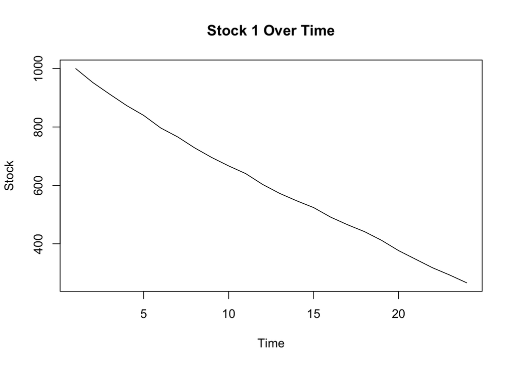

```r
# Run the model with opimal values
optimal_run <- run_model(optimal_values[1:SIMULATION_LENGTH], optimal_values[(SIMULATION_LENGTH+1):(2*SIMULATION_LENGTH)], EFFORT_CAP, INITIAL_STOCK, CARRYING_CAPACITY, GROWTH_RATE, HARVEST_CONSTANT, MIGRATION_CONSTANT, SIMULATION_LENGTH, RHO, UTIL_SCALING_CONSTANT)
# optimal_run <- run_model(, EFFORT_CAP, INITIAL_STOCK, CARRYING_CAPACITY, GROWTH_RATE, HARVEST_CONSTANT, MIGRATION_CONSTANT, SIMULATION_LENGTH)

# Plot the results

plot(optimal_run$stock1, type = "l", xlab = "Time", ylab = "Stock", main = "Stock 1 Over Time")
```

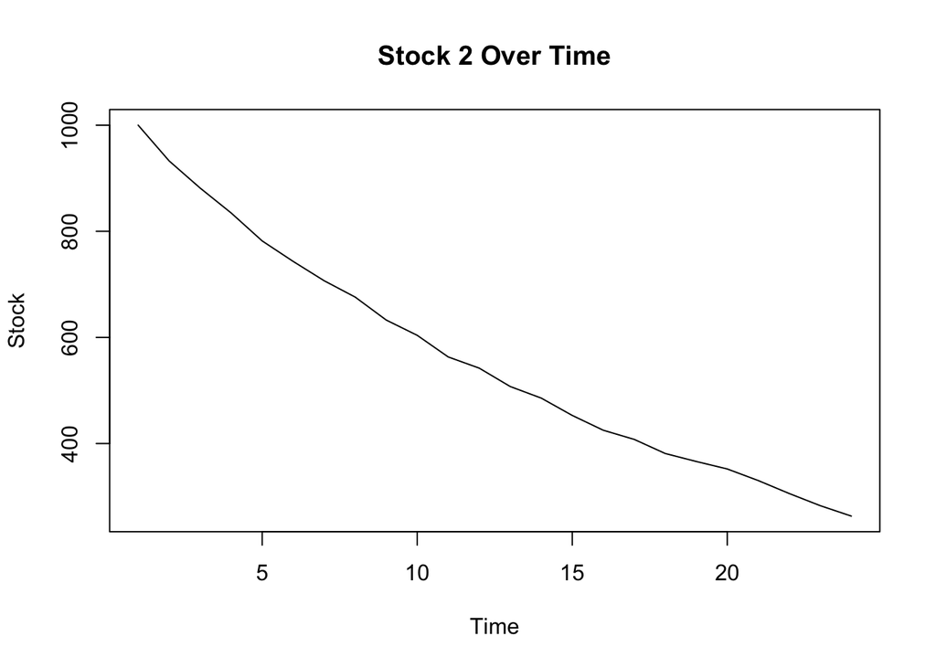

```r
plot(optimal_run$stock2, type = "l", xlab = "Time", ylab = "Stock", main = "Stock 2 Over Time")
```

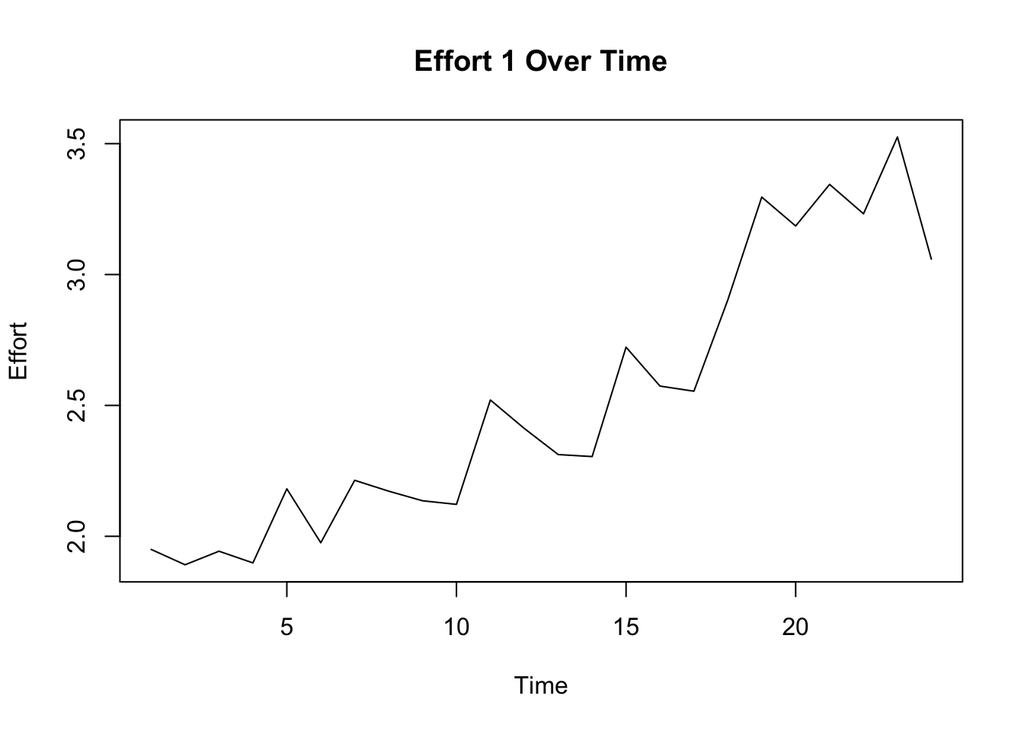

```r
# plot(optimal_run$harvest_1, type = "l", xlab = "Time", ylab = "Harvest", main = "Harvest 1 Over Time")
# plot(optimal_run$harvest_2, type = "l", xlab = "Time", ylab = "Harvest", main = "Harvest 2 Over Time")

plot(optimal_values[1:SIMULATION_LENGTH], type = "l", xlab = "Time", ylab = "Effort", main = "Effort 1 Over Time")
```

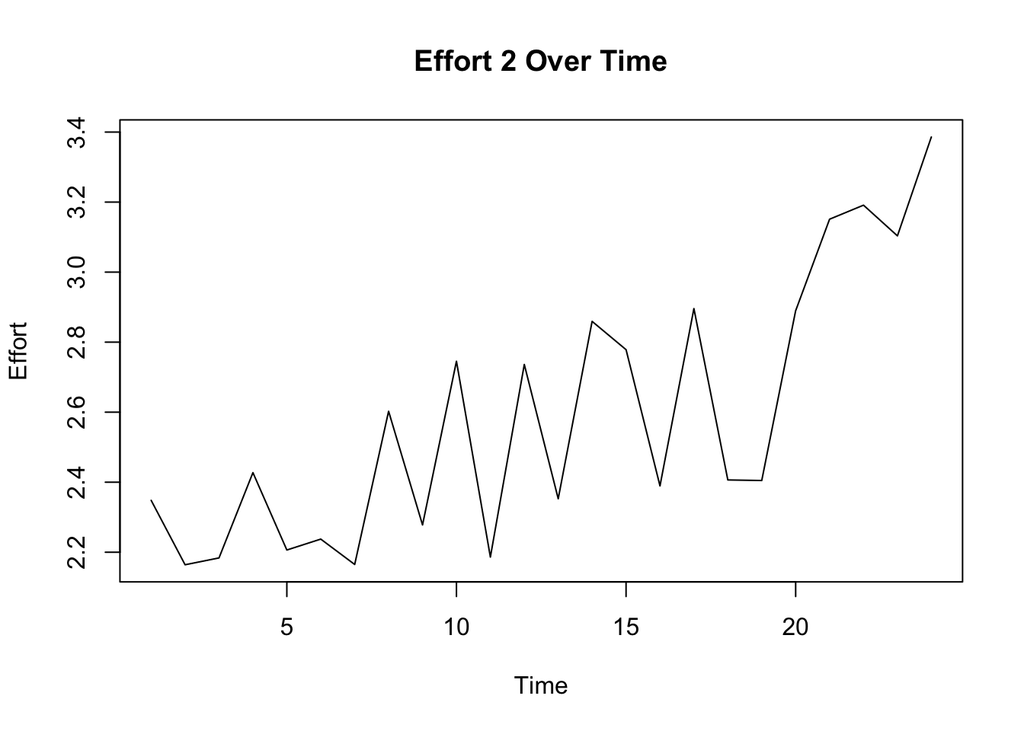

```r
plot(optimal_values[(SIMULATION_LENGTH+1):(2*SIMULATION_LENGTH)], type = "l", xlab = "Time", ylab = "Effort", main = "Effort 2 Over Time")
```

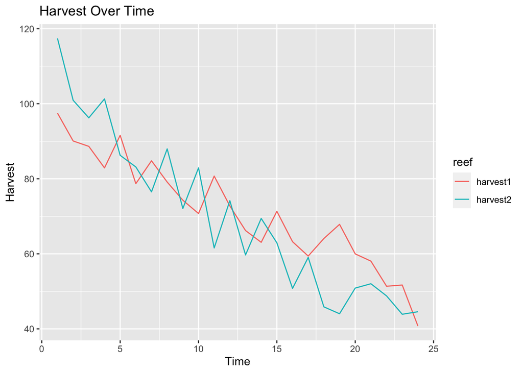

```r
# Plot harvest 1 and harvest 2 over time together on one graph
# use ggplot
harvest_data <- data.frame(time = 1:SIMULATION_LENGTH, harvest1 = optimal_run$harvest_1, harvest2 = optimal_run$harvest_2)
harvest_data <- gather(harvest_data, key = "reef", value = "harvest", -time)

ggplot(harvest_data, aes(x = time, y = harvest, color = reef)) + geom_line() + labs(title = "Harvest Over Time", x = "Time", y = "Harvest")
```